# Midterm

Haemin Lee

2023-02-19

# Midterm (Due Sunday 2/19/2023 at 11:55 pm)

Please submit your `.Rmd` and `.html` files in Sakai. If you are working together, both people should submit the files.

## 60 / 60 points total

The goal of the midterm project is to showcase skills that you have learned in class so far. The midterm is open note, but if you use someone else’s code, you **must attribute them**.

## Define Your Research Question (10 points)

> *Define your research question below. What about the data interests you? What is a specific question you want to find out about the data?*

**What topic did I choose?**  
When looking up data folders in Tidy Tuesday, I was interested in the topic of `US Drought` because the issue of climate change has always been on my mind. We had wildfires almost every late summer through fall and snowstorms last winter in Oregon.

**What do I want to know?**  
Thus, I want to know how severe the drought was in the United States continents, by 52 States, and by climate regions in the past. Plus, it would be interesting to compare drought severity levels over a long-term period in the Overall States and specific geographical areas.

**Research questions!**  
So, I have two points to look at in this study.

1. Do we have unusually severe drought in the United States over the past 23 years?  
2. Does the West region in the United States, including Oregon, have unusually severe drought compared to the past?

**The data I used.**  
I extracted the data from the US Drought Monitor site rather than using the data in the Tidy Tuesday in ordrt to set the specific time period and regions. The data source is, [U.S.Drought Monitor.](https://droughtmonitor.unl.edu/Data.aspx) To export the data from the website, I set the time from Feb.10.2000 to Feb.10.2023(for 23 years), setting “States” as a spatial scale.

> *Given your question, what is your expectation about the data?*

**1.** I expect the severity of the drought has been worse in the United States on average for the past 23 years. Still, there may be differences depending on geographical regions.  
**2.** I also expect the data to show a recent unusually severe drought in the West region.

## Loading the Data (10 points)

> *Load the data below and use `dplyr::glimpse()` or `skimr::skim()` on the data. You should upload the data file into the `data` directory.*

```r
# load the data
drought<- read_csv("data/drought_by_state.csv")
# check
glimpse(drought)
```

```
## Rows: 62,452
## Columns: 11
## $ MapDate           <dbl> 20230207, 20230131, 20230124, 20230117, 20230110, 20…
## $ StateAbbreviation <chr> "AK", "AK", "AK", "AK", "AK", "AK", "AK", "AK", "AK"…
## $ None              <dbl> 100.00, 100.00, 100.00, 100.00, 100.00, 100.00, 100.…
## $ D0                <dbl> 0.00, 0.00, 0.00, 0.00, 0.00, 0.00, 0.00, 0.00, 0.00…
## $ D1                <dbl> 0, 0, 0, 0, 0, 0, 0, 0, 0, 0, 0, 0, 0, 0, 0, 0, 0, 0…
## $ D2                <dbl> 0, 0, 0, 0, 0, 0, 0, 0, 0, 0, 0, 0, 0, 0, 0, 0, 0, 0…
## $ D3                <dbl> 0, 0, 0, 0, 0, 0, 0, 0, 0, 0, 0, 0, 0, 0, 0, 0, 0, 0…
## $ D4                <dbl> 0, 0, 0, 0, 0, 0, 0, 0, 0, 0, 0, 0, 0, 0, 0, 0, 0, 0…
## $ ValidStart        <date> 2023-02-07, 2023-01-31, 2023-01-24, 2023-01-17, 202…
## $ ValidEnd          <date> 2023-02-13, 2023-02-06, 2023-01-30, 2023-01-23, 202…
## $ StatisticFormatID <dbl> 2, 2, 2, 2, 2, 2, 2, 2, 2, 2, 2, 2, 2, 2, 2, 2, 2, 2…
```

> *If there are any quirks that you have to deal with `NA` coded as something else, or it is multiple tables, please make some notes here about what you need to do before you start transforming the data in the next section.*

In the original dataset, there are 62452 rows and 11 columns.

- `ValidStart` and `ValidEnd` are about the start and end dates. Also, `MapDate` takes the same value in the `ValidStart` but as a numeric value. I’ll change `MapDate` as date type.
- `StateAbbreviation` indicates 52 States in the United States with two letters.  
  For simplicity, I’ll change the column name to `state`. And then, I’ll make a new column, `Region` to classify States in the “West” Region or not because my second research interest focus on the “West” Region.  
  About the entire US climate region, we can refer to the explanation below from [National Centers for Environmental Information.](https://www.ncei.noaa.gov/regional/regional-climate-centers)
- `Region` can be classified as six climate regions in the United States continent, but here I’ll classify this into two categories as “West” or “Non West”.
  - **West**: Arizona, California, Idaho, Montana, Nevada, New Mexico, Oregon, Utah, Washington. (9 states)
  - **Non West**:
    - **High Plains**:Colorado, Kansas, Nebraska, North Dakota, South Dakota, and Wyoming (6 states)
    - **Midwest**: Illinois, Indiana, Iowa, Kentucky, Michigan, Minnesota, Missouri, Ohio, and Wisconsin (9 states)
    - **Northeast**: Maine, New Hampshire, Vermont, Massachusetts, Connecticut, Rhode Island, Delaware, New York, Pennsylvania, New Jersey, Maryland, and West Virginia and Washington D.C (13 states)
    - **South**: Arkansas, Tennessee, Texas, Louisiana, Mississippi, and Oklahoma. (6 states)
    - **Southeast**: Alabama, Florida, Georgia, North Carolina, South Carolina, Virginia, Puerto Rico and the U.S. Virgin Islands. (8 states)
- `None`, `D0`, `D1`, `D2`, `D3` and `D4` columns take percent(%) values which means what percent of the region are in each drought category. Therefore, the sum of these values in each observation should be 100(%). I will make a new column to check whether the sum is equal to 100.
  - `None` : No drought
  - `D0` : Abnormally Dry
  - `D1` : Moderate Drought
  - `D2` : Severe Drought
  - `D3` : Extreme Drought
  - `D4` : Exceptional Drought
- Check with `NA`s  
  We don’t have any missing value in the original dataset.

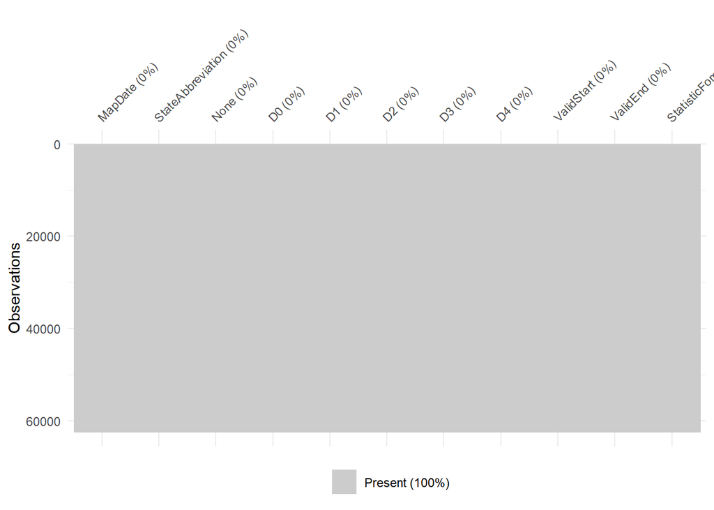

```r
# check NA's
visdat::vis_miss(drought)
```

- Drought Severity and Coverage Index (DSCI)  
  The Drought Severity and Coverage Index (DSCI) is a weighted sum of the proportion of each area in each level of drought, summarizing the extent and severity of drought with a single number each week on a scale from 0 (no drought) to 500 (all of the area in the worst category of drought). It can be computed as below;

  **0(None)+1(D0) + 2(D1) + 3(D2) + 4(D3) + 5(D4) = DSCI**

  Since there is no DSCI column in original dataset, I will make a new column, `DSCI` for analysis.

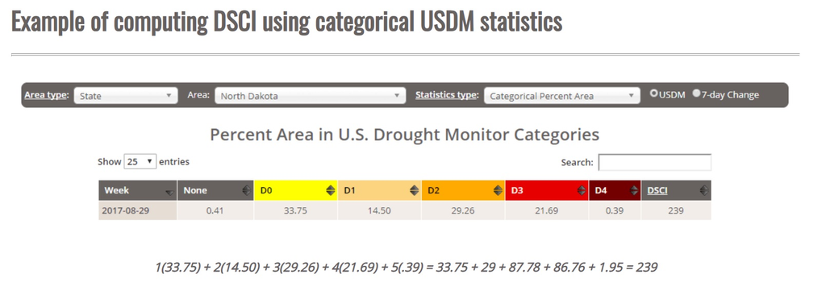

[Image Reference] [U.S.Drought Monitor.](https://droughtmonitor.unl.edu/Data.aspx)

> **Make sure your data types are correct!**

I think there is no problem in data types.

## Transforming the data (15 points)

> *If the data needs to be transformed in any way (values recoded, pivoted, etc), do it here. Examples include transforming a continuous variable into a categorical using `case_when()`, etc.*

```r
# mutate
drought_transformed <- drought %>%
  mutate(
  Date = ValidStart,
  Year = year(Date),
  Year = as.character(Year),         # extract `Year` and make a character value
  Month = month(Date),
  Month = as.character(Month),       # extract `Year` and make a character value
  state = StateAbbreviation,         # renaming a column
  Region = case_when(
    state %in% c("AZ","CA","ID","MT","NV","NM","OR","UT","WA") ~ "West",     # focus on West region
    TRUE ~                                                       "Non West"),
  Sum = None+D0+D1+D2+D3+D4,         # check `Sum` is 100(%)
  DSCI = 0*None+1*D0+2*D1+3*D2+4*D3+5*D4) %>%        # calculate the `DSCI` for each observation
  select(Date:Region,None:D4,Sum,DSCI)


# check
head(drought_transformed)
```

```
## # A tibble: 6 × 13
##   Date       Year  Month state Region   None    D0    D1    D2    D3    D4   Sum
##   <date>     <chr> <chr> <chr> <chr>   <dbl> <dbl> <dbl> <dbl> <dbl> <dbl> <dbl>
## 1 2023-02-07 2023  2     AK    Non We…   100     0     0     0     0     0   100
## 2 2023-01-31 2023  1     AK    Non We…   100     0     0     0     0     0   100
## 3 2023-01-24 2023  1     AK    Non We…   100     0     0     0     0     0   100
## 4 2023-01-17 2023  1     AK    Non We…   100     0     0     0     0     0   100
## 5 2023-01-10 2023  1     AK    Non We…   100     0     0     0     0     0   100
## 6 2023-01-03 2023  1     AK    Non We…   100     0     0     0     0     0   100
## # … with 1 more variable: DSCI <dbl>
```

> *Bonus points (5 points) for datasets that require merging of tables, but only if you reason through whether you should use `left_join`, `inner_join`, or `right_join` on these tables. No credit will be provided if you don’t.*

```r
# West region only
west <- drought_transformed %>%
  filter(Region == "West")

# check
west %>% tabyl(Region)
```

```
##  Region     n percent
##    West 10809       1
```

```r
# average DSCI by Year
avg_DSCI_year_west <- west %>%
  select(Year:Region,DSCI) %>%
  group_by(state, Year) %>%
  summarise(
    avg.DSCI.year = mean(DSCI))
# average DSCI by Year and Month
avg_DSCI_month_west <- west %>%
  select(Year:Region,DSCI) %>%
  group_by(state, Year, Month) %>%
  summarise(
    avg.DSCI.month = mean(DSCI))
# check
glimpse(avg_DSCI_year_west);glimpse(avg_DSCI_month_west)
```

```
## Rows: 216
## Columns: 3
## Groups: state [9]
## $ state         <chr> "AZ", "AZ", "AZ", "AZ", "AZ", "AZ", "AZ", "AZ", "AZ", "A…
## $ Year          <chr> "2000", "2001", "2002", "2003", "2004", "2005", "2006", …
## $ avg.DSCI.year <dbl> 77.734468, 2.011538, 306.964340, 315.805769, 306.002115,…
```

```
## Rows: 2,493
## Columns: 4
## Groups: state, Year [216]
## $ state          <chr> "AZ", "AZ", "AZ", "AZ", "AZ", "AZ", "AZ", "AZ", "AZ", "…
## $ Year           <chr> "2000", "2000", "2000", "2000", "2000", "2000", "2000",…
## $ Month          <chr> "10", "11", "12", "2", "3", "4", "5", "6", "7", "8", "9…
## $ avg.DSCI.month <dbl> 86.1760, 0.0000, 0.0000, 122.6400, 65.6100, 50.0325, 10…
```

```r
# left_join with west and avg_DSCI_year_west
join_west<- left_join(west, avg_DSCI_year_west, by = c("state","Year"))

# left_join with avg_DSCI_month_west
join_west <- left_join(join_west, avg_DSCI_month_west, by = c("state","Year","Month"))

# check
glimpse(join_west)
```

```
## Rows: 10,809
## Columns: 15
## $ Date           <date> 2023-02-07, 2023-01-31, 2023-01-24, 2023-01-17, 2023-0…
## $ Year           <chr> "2023", "2023", "2023", "2023", "2023", "2023", "2022",…
## $ Month          <chr> "2", "1", "1", "1", "1", "1", "12", "12", "12", "12", "…
## $ state          <chr> "AZ", "AZ", "AZ", "AZ", "AZ", "AZ", "AZ", "AZ", "AZ", "…
## $ Region         <chr> "West", "West", "West", "West", "West", "West", "West",…
## $ None           <dbl> 42.37, 42.37, 42.37, 42.20, 27.66, 12.40, 12.40, 12.40,…
## $ D0             <dbl> 36.30, 36.30, 36.30, 36.47, 40.65, 48.66, 48.64, 48.64,…
## $ D1             <dbl> 20.14, 20.18, 20.18, 20.18, 30.53, 31.09, 31.12, 31.12,…
## $ D2             <dbl> 1.19, 1.15, 1.15, 1.15, 1.16, 7.85, 7.85, 7.85, 7.85, 1…
## $ D3             <dbl> 0.00, 0.00, 0.00, 0.00, 0.00, 0.00, 0.00, 0.00, 0.00, 0…
## $ D4             <dbl> 0, 0, 0, 0, 0, 0, 0, 0, 0, 0, 0, 0, 0, 0, 0, 0, 0, 0, 0…
## $ Sum            <dbl> 100.00, 100.00, 100.00, 100.00, 100.00, 100.00, 100.01,…
## $ DSCI           <dbl> 80.15, 80.11, 80.11, 80.28, 105.19, 134.39, 134.43, 134…
## $ avg.DSCI.year  <dbl> 93.37167, 93.37167, 93.37167, 93.37167, 93.37167, 93.37…
## $ avg.DSCI.month <dbl> 80.1500, 96.0160, 96.0160, 96.0160, 96.0160, 96.0160, 1…
```

> *Show your transformed table here.* Use tools such as `glimpse()`, `skim()` or `head()` to illustrate your point.

```r
# 1st research question data (overall US)
skim(drought_transformed)
```

Data summary

| Name | drought_transformed |
| --- | --- |
| Number of rows | 62452 |
| Number of columns | 13 |
| _______________________ |  |
| Column type frequency: |  |
| character | 4 |
| Date | 1 |
| numeric | 8 |
| ________________________ |  |
| Group variables | None |

**Variable type: character**

| skim_variable | n_missing | complete_rate | min | max | empty | n_unique | whitespace |
| --- | --- | --- | --- | --- | --- | --- | --- |
| Year | 0 | 1 | 4 | 4 | 0 | 24 | 0 |
| Month | 0 | 1 | 1 | 2 | 0 | 12 | 0 |
| state | 0 | 1 | 2 | 2 | 0 | 52 | 0 |
| Region | 0 | 1 | 4 | 8 | 0 | 2 | 0 |

**Variable type: Date**

| skim_variable | n_missing | complete_rate | min | max | median | n_unique |
| --- | --- | --- | --- | --- | --- | --- |
| Date | 0 | 1 | 2000-02-08 | 2023-02-07 | 2011-08-09 | 1201 |

**Variable type: numeric**

| skim_variable | n_missing | complete_rate | mean | sd | p0 | p25 | p50 | p75 | p100 | hist |
| --- | --- | --- | --- | --- | --- | --- | --- | --- | --- | --- |
| None | 0 | 1 | 61.30 | 38.19 | 0.00 | 23.93 | 72.86 | 100.00 | 100.00 | ▅▂▂▂▇ |
| D0 | 0 | 1 | 16.67 | 20.01 | 0.00 | 0.00 | 10.04 | 26.64 | 100.00 | ▇▂▁▁▁ |
| D1 | 0 | 1 | 10.40 | 16.34 | 0.00 | 0.00 | 0.48 | 16.32 | 100.00 | ▇▂▁▁▁ |
| D2 | 0 | 1 | 6.88 | 14.17 | 0.00 | 0.00 | 0.00 | 6.68 | 100.00 | ▇▁▁▁▁ |
| D3 | 0 | 1 | 3.69 | 11.00 | 0.00 | 0.00 | 0.00 | 0.00 | 100.00 | ▇▁▁▁▁ |
| D4 | 0 | 1 | 1.07 | 5.87 | 0.00 | 0.00 | 0.00 | 0.00 | 87.99 | ▇▁▁▁▁ |
| Sum | 0 | 1 | 100.00 | 0.01 | 99.98 | 100.00 | 100.00 | 100.00 | 101.64 | ▇▁▁▁▁ |
| DSCI | 0 | 1 | 78.20 | 101.85 | 0.00 | 0.00 | 31.66 | 122.14 | 484.14 | ▇▂▁▁▁ |

```r
# 2nd research question data (West only)
skim(join_west)
```

Data summary

| Name | join_west |
| --- | --- |
| Number of rows | 10809 |
| Number of columns | 15 |
| _______________________ |  |
| Column type frequency: |  |
| character | 4 |
| Date | 1 |
| numeric | 10 |
| ________________________ |  |
| Group variables | None |

**Variable type: character**

| skim_variable | n_missing | complete_rate | min | max | empty | n_unique | whitespace |
| --- | --- | --- | --- | --- | --- | --- | --- |
| Year | 0 | 1 | 4 | 4 | 0 | 24 | 0 |
| Month | 0 | 1 | 1 | 2 | 0 | 12 | 0 |
| state | 0 | 1 | 2 | 2 | 0 | 9 | 0 |
| Region | 0 | 1 | 4 | 4 | 0 | 1 | 0 |

**Variable type: Date**

| skim_variable | n_missing | complete_rate | min | max | median | n_unique |
| --- | --- | --- | --- | --- | --- | --- |
| Date | 0 | 1 | 2000-02-08 | 2023-02-07 | 2011-08-09 | 1201 |

**Variable type: numeric**

| skim_variable | n_missing | complete_rate | mean | sd | p0 | p25 | p50 | p75 | p100 | hist |
| --- | --- | --- | --- | --- | --- | --- | --- | --- | --- | --- |
| None | 0 | 1 | 35.81 | 36.55 | 0.00 | 0.03 | 22.26 | 68.37 | 100.00 | ▇▂▂▂▃ |
| D0 | 0 | 1 | 18.60 | 18.76 | 0.00 | 2.15 | 14.24 | 28.91 | 100.00 | ▇▃▁▁▁ |
| D1 | 0 | 1 | 17.29 | 17.66 | 0.00 | 1.74 | 12.78 | 27.33 | 100.00 | ▇▃▁▁▁ |
| D2 | 0 | 1 | 15.91 | 19.08 | 0.00 | 0.00 | 9.02 | 26.71 | 100.00 | ▇▂▁▁▁ |
| D3 | 0 | 1 | 9.59 | 16.75 | 0.00 | 0.00 | 0.00 | 13.95 | 100.00 | ▇▂▁▁▁ |
| D4 | 0 | 1 | 2.79 | 9.21 | 0.00 | 0.00 | 0.00 | 0.00 | 76.81 | ▇▁▁▁▁ |
| Sum | 0 | 1 | 100.00 | 0.01 | 99.98 | 100.00 | 100.00 | 100.00 | 100.02 | ▁▂▇▂▁ |
| DSCI | 0 | 1 | 153.26 | 124.54 | 0.00 | 38.92 | 129.93 | 251.06 | 469.63 | ▇▅▃▃▁ |
| avg.DSCI.year | 0 | 1 | 153.26 | 110.88 | 1.43 | 58.64 | 127.18 | 244.34 | 431.46 | ▇▃▅▃▁ |
| avg.DSCI.month | 0 | 1 | 153.26 | 123.95 | 0.00 | 40.49 | 129.03 | 250.55 | 466.13 | ▇▅▃▃▁ |

> *Are the values what you expected for the variables? Why or Why not?*
- I expected that the sum of `None`,`D0`,`D1`,`D2`,`D3` and `D4` columns will be 100(%) because those indicate the proportion of the Climate Region classified as being in one of six levels of drought.
  - In the `drought_transformed` data, the `Sum` column consists values of 100s, and ranges from 99.98 to 101.64, with errors might be caused by measuring or rounding.
  - In the `join_west` data, the `Sum` column consists values of 100s, and ranges from 99.98 to 100.02, which is fairly close to 100.
- The range of `DSCI` should be from 0 to 500. And we can check this is true for two datasets.

## Visualizing and Summarizing the Data (15 points)

> *Use `group_by()` and `summarize()` to make a summary of the data here. The summary should be relevant to your research question*

To answer research questions, I grouped data by `state`, `Year`, and `Month` in order, and then summarized the average `DSCI` values.

```r
# fist summary
summary_state <- drought_transformed %>%
  select(Date:state,DSCI) %>%
  group_by(state, Year) %>%
  summarise(
    avg.DSCI = mean(DSCI)) %>%
  mutate(
    Year = as.numeric(Year))
# check
glimpse(summary_state)
```

```
## Rows: 1,248
## Columns: 3
## Groups: state [52]
## $ state    <chr> "AK", "AK", "AK", "AK", "AK", "AK", "AK", "AK", "AK", "AK", "…
## $ Year     <dbl> 2000, 2001, 2002, 2003, 2004, 2005, 2006, 2007, 2008, 2009, 2…
## $ avg.DSCI <dbl> 2.4893617, 0.2319231, 14.3100000, 13.5015385, 26.7409615, 4.0…
```

```r
# second summary ; already summarised() before
summary_west <- join_west %>%
  select(Date:Region,DSCI:avg.DSCI.month) %>%
  mutate(
    Year = as.numeric(Year),
    Month = as.numeric(Month))

# check
glimpse(summary_west)
```

```
## Rows: 10,809
## Columns: 8
## $ Date           <date> 2023-02-07, 2023-01-31, 2023-01-24, 2023-01-17, 2023-0…
## $ Year           <dbl> 2023, 2023, 2023, 2023, 2023, 2023, 2022, 2022, 2022, 2…
## $ Month          <dbl> 2, 1, 1, 1, 1, 1, 12, 12, 12, 12, 11, 11, 11, 11, 11, 1…
## $ state          <chr> "AZ", "AZ", "AZ", "AZ", "AZ", "AZ", "AZ", "AZ", "AZ", "…
## $ Region         <chr> "West", "West", "West", "West", "West", "West", "West",…
## $ DSCI           <dbl> 80.15, 80.11, 80.11, 80.28, 105.19, 134.39, 134.43, 134…
## $ avg.DSCI.year  <dbl> 93.37167, 93.37167, 93.37167, 93.37167, 93.37167, 93.37…
## $ avg.DSCI.month <dbl> 80.1500, 96.0160, 96.0160, 96.0160, 96.0160, 96.0160, 1…
```

> *What are your findings about the summary? Are they what you expected?*

Because my research questions are about change in drought severity by time for 23 years, I need to visualize the data to find answers.

> *Make at least two plots that help you answer your question on the transformed or summarized data. Use scales and/or labels to make each plot informative.*

The first question was,  
**1. Do we have unusually severe drought in the United States over the past 23 years?**

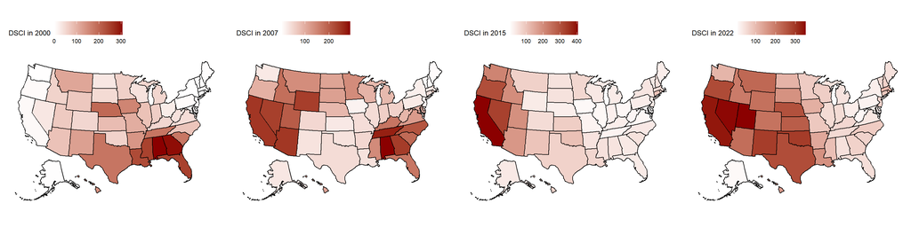

```r
# Reference for following r codes: BSTA512 lecture notes by Dr.Meike

# plot for 2000
usmap_2000 <- plot_usmap(
  data = summary_state %>% filter(Year == 2000),
  regions = "state",
  values = "avg.DSCI")+
  scale_fill_gradient2(
    low = "white",
    high = "darkred",
    name = "DSCI in 2000")+
   theme(legend.position = "top")


# plot for 2007
usmap_2007 <- plot_usmap(
  data = summary_state %>% filter(Year == 2007),
  regions = "state",
  values = "avg.DSCI")+
  scale_fill_gradient2(
    low = "white",
    high = "darkred",
    name = "DSCI in 2007")+
   theme(legend.position = "top")


# plot for 2015
usmap_2015 <- plot_usmap(
  data = summary_state %>% filter(Year == 2015),
  regions = "state",
  values = "avg.DSCI")+
  scale_fill_gradient2(
    low = "white",
    high = "darkred",
    name = "DSCI in 2015")+
   theme(legend.position = "top")


# plot for 2022
usmap_2022 <- plot_usmap(
  data = summary_state %>% filter(Year == 2022),
  regions = "state",
  values = "avg.DSCI")+
  scale_fill_gradient2(
    low = "white",
    high = "darkred",
    name = "DSCI in 2022")+
   theme(legend.position = "top")



# arrange plots
gridExtra::grid.arrange(usmap_2000,usmap_2007,usmap_2015,usmap_2022,
                        ncol = 4)
```

The second question was,  
**2. Does the West region in the United States, including Oregon, have unusually severe drought compared to the past?**

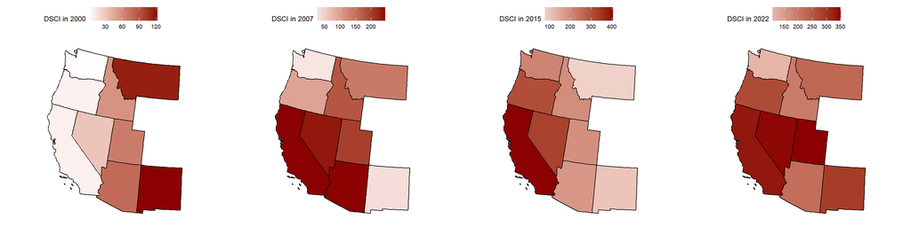

```r
# plot for 2000
westmap_2000 <- plot_usmap(
  include = c("AZ","CA","ID","MT","NM","NV","OR","UT","WA"),
  data = summary_west %>% filter(Year == 2000),
  regions = "state",
  values = "avg.DSCI.year")+
  scale_fill_gradient2(
    low = "white",
    high = "darkred",
    name = "DSCI in 2000")+
   theme(legend.position = "top")


# plot for 2007
westmap_2007 <- plot_usmap(
  include = c("AZ","CA","ID","MT","NM","NV","OR","UT","WA"),
  data = summary_west %>% filter(Year == 2007),
  regions = "state",
  values = "avg.DSCI.year")+
  scale_fill_gradient2(
    low = "white",
    high = "darkred",
    name = "DSCI in 2007")+
   theme(legend.position = "top")


# plot for 2015
westmap_2015 <- plot_usmap(
  include = c("AZ","CA","ID","MT","NM","NV","OR","UT","WA"),
  data = summary_west %>% filter(Year == 2015),
  regions = "state",
  values = "avg.DSCI.year")+
  scale_fill_gradient2(
    low = "white",
    high = "darkred",
    name = "DSCI in 2015")+
   theme(legend.position = "top")


# plot for 2022
westmap_2022 <- plot_usmap(
  include = c("AZ","CA","ID","MT","NM","NV","OR","UT","WA"),
  data = summary_west %>% filter(Year == 2022),
  regions = "state",
  values = "avg.DSCI.year")+
  scale_fill_gradient2(
    low = "white",
    high = "darkred",
    name = "DSCI in 2022")+
   theme(legend.position = "top")



# arrange plots
gridExtra::grid.arrange(westmap_2000,westmap_2007,westmap_2015,westmap_2022,
                        ncol = 4)
```

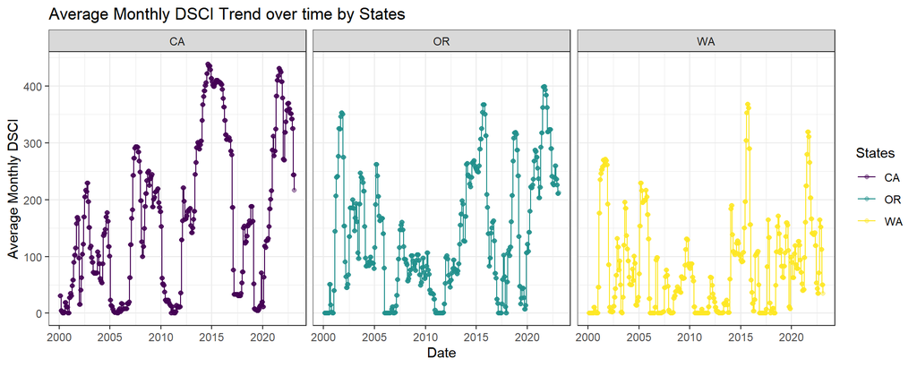

```r
# subset for three States, OR, CA, and WA
summary_west_3 <- summary_west %>%
  filter(state %in% c("OR","CA","WA")) %>%
  mutate(state = as.factor(state))


# Compare plot
ggplot(summary_west_3,
       aes(x = Date ,y = avg.DSCI.month, col = state, group = state))+
  geom_point(alpha=0.4)+
  geom_line()+
  theme_bw()+
  scale_color_viridis_d(name ="States")+
  facet_wrap(~state)+
  labs(
    title = "Average Monthly DSCI Trend over time by States",
    y = "Average Monthly DSCI",
    X = "Time")
```

Lastly, comparing drought trends in three States, Oregon, California, and Washington, would be interesting from my interest. So, using a subset of the data, I created a plot for each State showing monthly average DSCI trends over 23 years. In the output above, three States share the same increasing trends over time. Still, the increasing trend in monthly average DSCI is most considerable in California(CA) and most minor in Washington(WA). Oregon(OR) is in the middle.

## Final Summary (10 points)

> *Summarize your research question and findings below.*

Answers for research questions are above with plots.

> *Are your findings what you expected? Why or Why not?*